# Assignment 2

Date: October 11, 2023

Notice:

- Due date: 11:59 p.m. Wednesday, October 25, 2023.
- Please submit your solutions on Canvas.
- Two files are required on submission:
  - A **.pdf** file that includes all the conceptual parts. You may take photos of your handwriting hardcopy and compile them into a **.pdf** file.
  - An **.html**/**.pdf** file automatically generated by **.ipynb/.Rmd** file that includes all the codes and results for the coding part. You will get zero marks in this part if you do not meet the format requirement.
  - The raw **.ipynb/.Rmd** file is **optional**.
  - Write your code in a modular, readable way. Code organization will be taken into account for the grading.

## Exercises from the reference book

- Chapter 4: 1, 2, 3, 13, 14.
- Chapter 5: 1, 2, 5, 6.

**Please ensure you are using the second edition of the book, which can be downloaded [here](https://www.statlearning.com/).**

## Question 4.13

```python
import numpy as np
import pandas as pd
from ISLP import load_data
import matplotlib.pyplot as plt
import seaborn as sns
from sklearn.metrics import confusion_matrix
import statsmodels.api as sm
from sklearn.linear_model import LogisticRegression
from ISLP.models import (ModelSpec as MS, summarize)
from sklearn.discriminant_analysis import \
     (LinearDiscriminantAnalysis as LDA,
      QuadraticDiscriminantAnalysis as QDA)
import ISLP
from sklearn.naive_bayes import GaussianNB
import statsmodels.formula.api as smf
from sklearn import neighbors, preprocessing
from patsy import dmatrices
import patsy
weekly = load_data("Weekly")
weekly.head()
```

|  | Year | Lag1 | Lag2 | Lag3 | Lag4 | Lag5 | Volume | Today | Direction |
| --- | --- | --- | --- | --- | --- | --- | --- | --- | --- |
| 0 | 1990 | 0.816 | 1.572 | -3.936 | -0.229 | -3.484 | 0.154976 | -0.270 | Down |
| 1 | 1990 | -0.270 | 0.816 | 1.572 | -3.936 | -0.229 | 0.148574 | -2.576 | Down |
| 2 | 1990 | -2.576 | -0.270 | 0.816 | 1.572 | -3.936 | 0.159837 | 3.514 | Up |
| 3 | 1990 | 3.514 | -2.576 | -0.270 | 0.816 | 1.572 | 0.161630 | 0.712 | Up |
| 4 | 1990 | 0.712 | 3.514 | -2.576 | -0.270 | 0.816 | 0.153728 | 1.178 | Up |

### (a).

```python
weekly.info()
```

```
<class 'pandas.core.frame.DataFrame'>
RangeIndex: 1089 entries, 0 to 1088
Data columns (total 9 columns):
 #   Column     Non-Null Count  Dtype
---  ------     --------------  -----
 0   Year       1089 non-null   int64
 1   Lag1       1089 non-null   float64
 2   Lag2       1089 non-null   float64
 3   Lag3       1089 non-null   float64
 4   Lag4       1089 non-null   float64
 5   Lag5       1089 non-null   float64
 6   Volume     1089 non-null   float64
 7   Today      1089 non-null   float64
 8   Direction  1089 non-null   category
dtypes: category(1), float64(7), int64(1)
memory usage: 69.4 KB
```

**Observation**: Hand on the dataset by knowing the datatypes of each attributes. From above we could observe that the attributes `Year`, `Lag1`, `Lag2`, `Lag3`, `Lag4`, `Lag5`, `Volume`, `Today` are of type `int64` and `float64`, which means they are numerical. And Direction is of type `category`, which means it is a categorical variable.

```python
weekly.isnull().sum()
```

```
Year         0
Lag1         0
Lag2         0
Lag3         0
Lag4         0
Lag5         0
Volume       0
Today        0
Direction    0
dtype: int64
```

**Observation**: There are no null values in each attributes.

```
              Year         Lag1         Lag2         Lag3         Lag4  \
count  1089.000000  1089.000000  1089.000000  1089.000000  1089.000000
mean   2000.048669     0.150585     0.151079     0.147205     0.145818
std       6.033182     2.357013     2.357254     2.360502     2.360279
min    1990.000000   -18.195000   -18.195000   -18.195000   -18.195000
25%    1995.000000    -1.154000    -1.154000    -1.158000    -1.158000
50%    2000.000000     0.241000     0.241000     0.241000     0.238000
75%    2005.000000     1.405000     1.409000     1.409000     1.409000
max    2010.000000    12.026000    12.026000    12.026000    12.026000

              Lag5       Volume        Today
count  1089.000000  1089.000000  1089.000000
mean      0.139893     1.574618     0.149899
std       2.361285     1.686636     2.356927
min     -18.195000     0.087465   -18.195000
25%      -1.166000     0.332022    -1.154000
50%       0.234000     1.002680     0.241000
75%       1.405000     2.053727     1.405000
max      12.026000     9.328214    12.026000
```

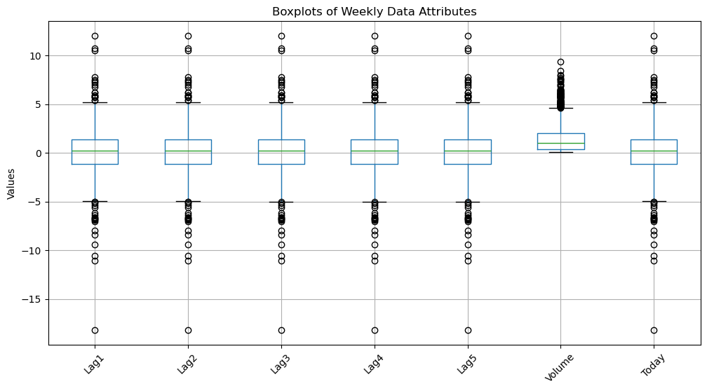

```python
print(weekly.describe())
numeric_cols = ['Lag1', 'Lag2', 'Lag3', 'Lag4', 'Lag5', 'Volume', 'Today']
plt.figure(figsize=(12, 6))
weekly[numeric_cols].boxplot()
plt.xticks(rotation=45)
plt.title('Boxplots of Weekly Data Attributes')
plt.ylabel('Values')
plt.show()
```

```
            Year      Lag1      Lag2      Lag3      Lag4      Lag5    Volume  \
Year    1.000000 -0.032289 -0.033390 -0.030006 -0.031128 -0.030519  0.841942
Lag1   -0.032289  1.000000 -0.074853  0.058636 -0.071274 -0.008183 -0.064951
Lag2   -0.033390 -0.074853  1.000000 -0.075721  0.058382 -0.072499 -0.085513
Lag3   -0.030006  0.058636 -0.075721  1.000000 -0.075396  0.060657 -0.069288
Lag4   -0.031128 -0.071274  0.058382 -0.075396  1.000000 -0.075675 -0.061075
Lag5   -0.030519 -0.008183 -0.072499  0.060657 -0.075675  1.000000 -0.058517
Volume  0.841942 -0.064951 -0.085513 -0.069288 -0.061075 -0.058517  1.000000
Today  -0.032460 -0.075032  0.059167 -0.071244 -0.007826  0.011013 -0.033078

           Today
Year   -0.032460
Lag1   -0.075032
Lag2    0.059167
Lag3   -0.071244
Lag4   -0.007826
Lag5    0.011013
Volume -0.033078
Today   1.000000
```

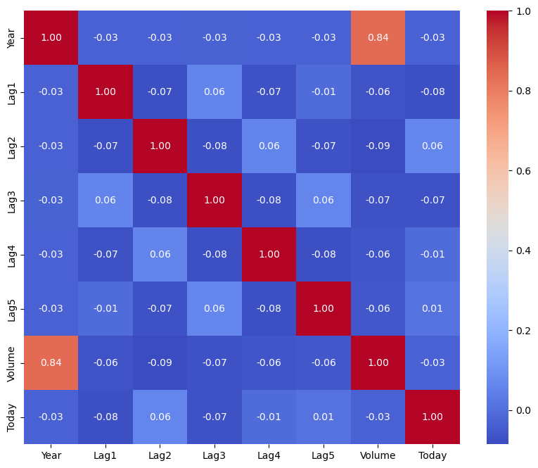

```python
corr_matrix = weekly.corr(numeric_only=True)
print(corr_matrix)
plt.figure(figsize=(10, 8))
sns.heatmap(corr_matrix, annot=True, cmap='coolwarm', fmt='.2f')
plt.show()
```

**Observation**: From the correlation matrix, we could observe that `Year` and `Volume` are highly correlated with each other

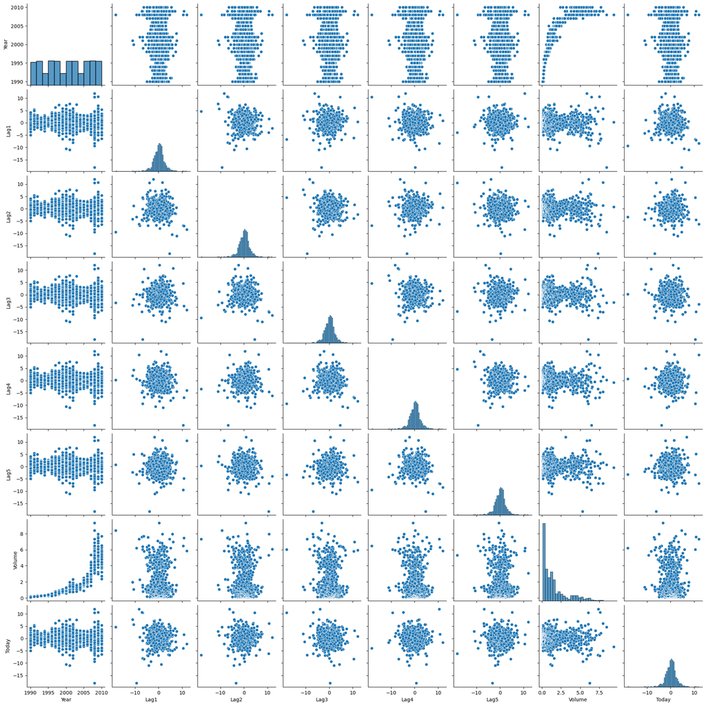

```python
sns.pairplot(weekly)
```

**Summarize**:

- The `Year` and `Volume` are highly correlated with each other.
- From the plot of "Volumn" vs "Year", we could observe that the trend of "Volume" is increasing significantly over the years.

### (b).

```python
lg_fit = smf.glm('Direction~Lag1+Lag2+Lag3+Lag4+Lag5+Volume',
                data=weekly,
                family=sm.families.Binomial()).fit()
lg_fit.summary()
```

Generalized Linear Model Regression Results

| Dep. Variable: | ['Direction[Down]', 'Direction[Up]'] | No. Observations: | 1089 |
| --- | --- | --- | --- |
| Model: | GLM | Df Residuals: | 1082 |
| Model Family: | Binomial | Df Model: | 6 |
| Link Function: | Logit | Scale: | 1.0000 |
| Method: | IRLS | Log-Likelihood: | -743.18 |
| Date: | Mon, 04 Nov 2024 | Deviance: | 1486.4 |
| Time: | 22:18:22 | Pearson chi2: | 1.09e+03 |
| No. Iterations: | 4 | Pseudo R-squ. (CS): | 0.009000 |
| Covariance Type: | nonrobust |  |  |

|  | coef | std err | z | P>\|z\| | [0.025 | 0.975] |
| --- | --- | --- | --- | --- | --- | --- |
| Intercept | -0.2669 | 0.086 | -3.106 | 0.002 | -0.435 | -0.098 |
| Lag1 | 0.0413 | 0.026 | 1.563 | 0.118 | -0.010 | 0.093 |
| Lag2 | -0.0584 | 0.027 | -2.175 | 0.030 | -0.111 | -0.006 |
| Lag3 | 0.0161 | 0.027 | 0.602 | 0.547 | -0.036 | 0.068 |
| Lag4 | 0.0278 | 0.026 | 1.050 | 0.294 | -0.024 | 0.080 |
| Lag5 | 0.0145 | 0.026 | 0.549 | 0.583 | -0.037 | 0.066 |
| Volume | 0.0227 | 0.037 | 0.616 | 0.538 | -0.050 | 0.095 |

**Answer**: It would seem that “Lag2” is the only predictor statistically significant since its |p-value| is less than 0.05.

### (c).

- Confusion matrix:

```python
lg_pred = np.where(lg_fit.fittedvalues>0.5, 'Down', 'Up')
real_direction = weekly['Direction']
ISLP.confusion_table(real_direction, lg_pred)
```

| Truth Predicted | Down | Up |
| --- | --- | --- |
| Down | 54 | 430 |
| Up | 48 | 557 |

- Overall fraction of correct predictions:

```python
True_Down = 54
False_Down = 430
False_Up = 48
True_Up = 557
correct_predictions = True_Down + True_Up
total_predictions = True_Down + False_Down + False_Up + True_Up
accuracy = correct_predictions / total_predictions

accuracy
```

```
0.5610651974288338
```

### Additional Metrics to Consider:

While the confusion matrix is informative, computing additional metrics will provide a more comprehensive understanding of the model's strengths and weaknesses:

1. **Precision for Up**: $$ \text{Precision} = \frac{\text{True Positives (TP)}}{\text{True Positives (TP)} + \text{False Positives (FP)}} = \frac{557}{557 + 430} \approx 0.564 $$ Precision indicates that when the model predicts Up, it is correct **56.4%** of the time.
2. **Recall for Up**: $$ \text{Recall} = \frac{\text{True Positives (TP)}}{\text{True Positives (TP)} + \text{False Negatives (FN)}} = \frac{557}{557 + 48} \approx 0.921 $$ Recall shows that the model successfully identifies **92.1%** of the actual Up cases, meaning it has a strong ability to detect Up movements.
3. **Specificity for Down**: $$ \text{Specificity} = \frac{\text{True Negatives (TN)}}{\text{True Negatives (TN)} + \text{False Positives (FP)}} = \frac{54}{54 + 430} \approx 0.112 $$ Specificity indicates that the model correctly identifies Down cases only **11.2%** of the time, showing that it struggles significantly with predicting when the market will go down.

### Conclusion:

The confusion matrix reveals that the logistic regression model has a strong **bias towards predicting Up**. It has **high recall for Up predictions** (92.1%), meaning it correctly identifies the majority of Up cases, but this comes at the cost of producing **many false positives** (predicting Up when it should be Down). This leads to a relatively low precision for Up (56.4%) and a very **low specificity** for Down (11.2%), indicating that the model is not effective at predicting market downturns. These results suggest that while the model performs well in identifying Up movements, it performs poorly in capturing Down movements, which could be problematic if identifying market declines is crucial.

### (d).

```python
train = weekly['Year']<2009
test_set = weekly[~train]
lg_fit = smf.glm('Direction~Lag2',
                data=weekly,
                subset=train,
                family=sm.families.Binomial()).fit()
lg_fit.summary()
```

Generalized Linear Model Regression Results

| Dep. Variable: | ['Direction[Down]', 'Direction[Up]'] | No. Observations: | 985 |
| --- | --- | --- | --- |
| Model: | GLM | Df Residuals: | 983 |
| Model Family: | Binomial | Df Model: | 1 |
| Link Function: | Logit | Scale: | 1.0000 |
| Method: | IRLS | Log-Likelihood: | -675.27 |
| Date: | Mon, 04 Nov 2024 | Deviance: | 1350.5 |
| Time: | 22:18:22 | Pearson chi2: | 985. |
| No. Iterations: | 4 | Pseudo R-squ. (CS): | 0.004221 |
| Covariance Type: | nonrobust |  |  |

|  | coef | std err | z | P>\|z\| | [0.025 | 0.975] |
| --- | --- | --- | --- | --- | --- | --- |
| Intercept | -0.2033 | 0.064 | -3.162 | 0.002 | -0.329 | -0.077 |
| Lag2 | -0.0581 | 0.029 | -2.024 | 0.043 | -0.114 | -0.002 |

```python
lg_prob = lg_fit.predict(test_set)
lg_pred = np.where(lg_prob>0.5,
                  'Down', 'Up')
real_direction = test_set['Direction']
confusion_matrix(real_direction, lg_pred)
```

```
array([[ 9, 34],
       [ 5, 56]])
```

Overall accuracy: (9+56)/(9+56+34+5) = 62.5%

In this case, we can conclude that the percentage of correct predictions on the test data is

$\frac{9 + 56}{104} = 62.5\%$

which is equal to 62.5%. In other words, 37.5% is the test error rate. We can also say that for weeks when the market goes up, the model is right 91.8032787% of the time

$\frac{56}{56 + 5} = 91.8\%$.

For weeks when the market goes down, the model is right only 20.9302326% of the time

$\frac{9}{9 + 34} = 20.9\%$.

### (e).

```python
X_train = weekly[train][['Lag2']]
y_train = weekly[train]['Direction']

X_test = test_set[['Lag2']]
y_test = test_set['Direction']

lda = LDA(store_covariance=True)
lda_fit = lda.fit(X_train, y_train)

lda_pred = lda_fit.predict(X_test)
ISLP.confusion_table(y_test, lda_pred)
```

| Truth Predicted | Down | Up |
| --- | --- | --- |
| Down | 9 | 34 |
| Up | 5 | 56 |

**Observation**: It's same with logistic regression, the accuracy is 62.5%.

### (f).

```python
qda = QDA()
qda_fit = qda.fit(X_train, y_train)

qda_pred = qda_fit.predict(X_test)
ISLP.confusion_table(y_test, qda_pred)
```

| Truth Predicted | Down | Up |
| --- | --- | --- |
| Down | 0 | 43 |
| Up | 0 | 61 |

In this case, we can conclude that the model's percentage of correct predictions on the test data is

$58.6538462\%$.

In other words, the test error rate is

$41.3461538\%$.

Additionally, when the market goes up, the model is perfectly accurate with a correctness of

$100\%$.

However, for weeks when the market goes down, the model fails completely, with an accuracy of

$0\%$.

It is important to note that the model consistently predicts "Up" for the entire test period, yet it still achieves an overall correctness of

$58.6538462\%$ despite its inability to predict market downturns.

### (g).

```python
knn = neighbors.KNeighborsClassifier(n_neighbors=1)
knn_pred = knn.fit(X_train, y_train)\
              .predict(X_test)
ISLP.confusion_table(y_test, knn_pred)
```

| Truth Predicted | Down | Up |
| --- | --- | --- |
| Down | 21 | 22 |
| Up | 30 | 31 |

Accuracy: 50%

The **precision for Down** is

$\frac{21}{21 + 30} \approx 0.412$,

indicating that when the model predicts Down, it's correct **41.2%** of the time. The **recall for Down** is

$\frac{21}{21 + 22} \approx 0.488$,

showing that the model correctly identifies **48.8%** of actual Down cases. For Up predictions, the **precision** is

$\frac{31}{31 + 22} \approx 0.585$,

and the **recall for Up** is

$\frac{31}{31 + 30} \approx 0.508$.

Overall, the model's performance is fairly balanced, but there is room for improvement, particularly in its accuracy and ability to correctly identify Down cases.

### (h).

```python
NB = GaussianNB()
NB_fit = NB.fit(X_train, y_train)
NB_pred=NB_fit.predict(X_test)
ISLP.confusion_table(y_test, NB_pred)
```

| Truth Predicted | Down | Up |
| --- | --- | --- |
| Down | 0 | 43 |
| Up | 0 | 61 |

Overall accuracy: 58.65%

### (i).

Since the logistic regression and the LDA have the lowest test error rate, these two methods appear to provide the best results on this data.

### (j).

Logistic Regression:

```python
lg_fit3 = smf.glm('Direction~Lag1*Lag2',
                 data=weekly,
                 subset=train,
                 family=sm.families.Binomial()).fit()
lg_fit3_prob = lg_fit3.predict(test_set)
lg_fit3_pred = np.where(lg_fit3_prob>0.5,
                       'Down', 'Up')
ISLP.confusion_table(y_test, lg_fit3_pred)
```

| Truth Predicted | Down | Up |
| --- | --- | --- |
| Down | 7 | 36 |
| Up | 8 | 53 |

```python
(y_test == lg_fit3_pred).mean()
```

```
0.5769230769230769
```

LDA:

```python
formula = 'Direction~Lag1*Lag2'
y, X = patsy.dmatrices(formula, weekly, return_type='matrix')
lda = LDA()
lda_fit3 = lda.fit(X, y[:,0])
y_test1, X_test1 = patsy.dmatrices(formula, test_set, return_type='matrix')
lda_pred = lda_fit3.predict(X_test1)
lda_pred = np.where(lda_pred==1, 'Down', 'Up')
ISLP.confusion_table(test_set['Direction'], lda_pred)
```

| Truth Predicted | Down | Up |
| --- | --- | --- |
| Down | 5 | 38 |
| Up | 6 | 55 |

```python
(lda_pred == test_set['Direction']).mean()
```

```
0.5769230769230769
```

QDA:

```python
formula = 'Direction~Lag2+np.sqrt(np.abs(Lag2))'
y, X = patsy.dmatrices(formula, weekly, return_type='matrix')
qda = QDA()
qda_fit3 = qda.fit(X, y[:,0])
y_test1, X_test1 = patsy.dmatrices(formula, test_set, return_type='matrix')
qda_pred = qda_fit3.predict(X_test1)
qda_pred = np.where(qda_pred==1, 'Down', 'Up')
ISLP.confusion_table(test_set['Direction'], qda_pred)
```

| Truth Predicted | Down | Up |
| --- | --- | --- |
| Down | 0 | 43 |
| Up | 0 | 61 |

```python
(qda_pred == test_set['Direction']).mean()
```

```
0.5865384615384616
```

KNN:

```python
knn = neighbors.KNeighborsClassifier(n_neighbors=10)
knn_fit = knn.fit(X_train, y_train)\
             .predict(X_test)
print(ISLP.confusion_table(y_test, knn_fit))

(y_test == knn_fit).mean()
```

```
Truth      Down  Up
Predicted
Down         22  21
Up           24  37
```

```
0.5673076923076923
```

```python
knn = neighbors.KNeighborsClassifier(n_neighbors=100)
knn_fit = knn.fit(X_train, y_train)\
             .predict(X_test)
print(ISLP.confusion_table(y_test, knn_fit))

(y_test == knn_fit).mean()
```

```
Truth      Down  Up
Predicted
Down         11  32
Up           13  48
```

```
0.5673076923076923
```

Since the original logistic regression and LDA have the lowest test error rates, they have the best performance.

## Question 4.14

(a).

```python
auto = pd.read_csv('Auto.csv',
                  na_values='?',
                  index_col=0).dropna().reset_index()
auto.head()
```

|  | mpg | cylinders | displacement | horsepower | weight | acceleration | year | origin | name |
| --- | --- | --- | --- | --- | --- | --- | --- | --- | --- |
| 0 | 18.0 | 8 | 307.0 | 130.0 | 3504 | 12.0 | 70 | 1 | chevrolet chevelle malibu |
| 1 | 15.0 | 8 | 350.0 | 165.0 | 3693 | 11.5 | 70 | 1 | buick skylark 320 |
| 2 | 18.0 | 8 | 318.0 | 150.0 | 3436 | 11.0 | 70 | 1 | plymouth satellite |
| 3 | 16.0 | 8 | 304.0 | 150.0 | 3433 | 12.0 | 70 | 1 | amc rebel sst |
| 4 | 17.0 | 8 | 302.0 | 140.0 | 3449 | 10.5 | 70 | 1 | ford torino |

```python
mpg_median = auto.mpg.median()
auto['mpg01'] = np.where(auto.mpg>=mpg_median, 1, 0)
auto.head()
```

|  | mpg | cylinders | displacement | horsepower | weight | acceleration | year | origin | name | mpg01 |
| --- | --- | --- | --- | --- | --- | --- | --- | --- | --- | --- |
| 0 | 18.0 | 8 | 307.0 | 130.0 | 3504 | 12.0 | 70 | 1 | chevrolet chevelle malibu | 0 |
| 1 | 15.0 | 8 | 350.0 | 165.0 | 3693 | 11.5 | 70 | 1 | buick skylark 320 | 0 |
| 2 | 18.0 | 8 | 318.0 | 150.0 | 3436 | 11.0 | 70 | 1 | plymouth satellite | 0 |
| 3 | 16.0 | 8 | 304.0 | 150.0 | 3433 | 12.0 | 70 | 1 | amc rebel sst | 0 |
| 4 | 17.0 | 8 | 302.0 | 140.0 | 3449 | 10.5 | 70 | 1 | ford torino | 0 |

(b).

```python
auto_number = auto.select_dtypes(include=['number'])
corr_matrix = auto_number.corr()
corr_matrix
```

|  | mpg | cylinders | displacement | horsepower | weight | acceleration | year | origin | mpg01 |
| --- | --- | --- | --- | --- | --- | --- | --- | --- | --- |
| mpg | 1.000000 | -0.777618 | -0.805127 | -0.778427 | -0.832244 | 0.423329 | 0.580541 | 0.565209 | 0.836939 |
| cylinders | -0.777618 | 1.000000 | 0.950823 | 0.842983 | 0.897527 | -0.504683 | -0.345647 | -0.568932 | -0.759194 |
| displacement | -0.805127 | 0.950823 | 1.000000 | 0.897257 | 0.932994 | -0.543800 | -0.369855 | -0.614535 | -0.753477 |
| horsepower | -0.778427 | 0.842983 | 0.897257 | 1.000000 | 0.864538 | -0.689196 | -0.416361 | -0.455171 | -0.667053 |
| weight | -0.832244 | 0.897527 | 0.932994 | 0.864538 | 1.000000 | -0.416839 | -0.309120 | -0.585005 | -0.757757 |
| acceleration | 0.423329 | -0.504683 | -0.543800 | -0.689196 | -0.416839 | 1.000000 | 0.290316 | 0.212746 | 0.346822 |
| year | 0.580541 | -0.345647 | -0.369855 | -0.416361 | -0.309120 | 0.290316 | 1.000000 | 0.181528 | 0.429904 |
| origin | 0.565209 | -0.568932 | -0.614535 | -0.455171 | -0.585005 | 0.212746 | 0.181528 | 1.000000 | 0.513698 |
| mpg01 | 0.836939 | -0.759194 | -0.753477 | -0.667053 | -0.757757 | 0.346822 | 0.429904 | 0.513698 | 1.000000 |

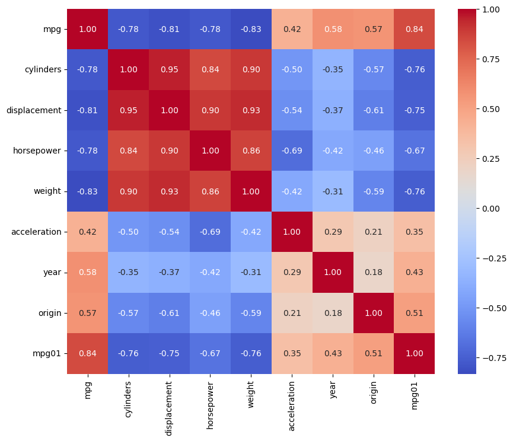

```python
plt.figure(figsize=(10, 8))
sns.heatmap(corr_matrix, annot=True, cmap='coolwarm', fmt='.2f')
plt.show()
```

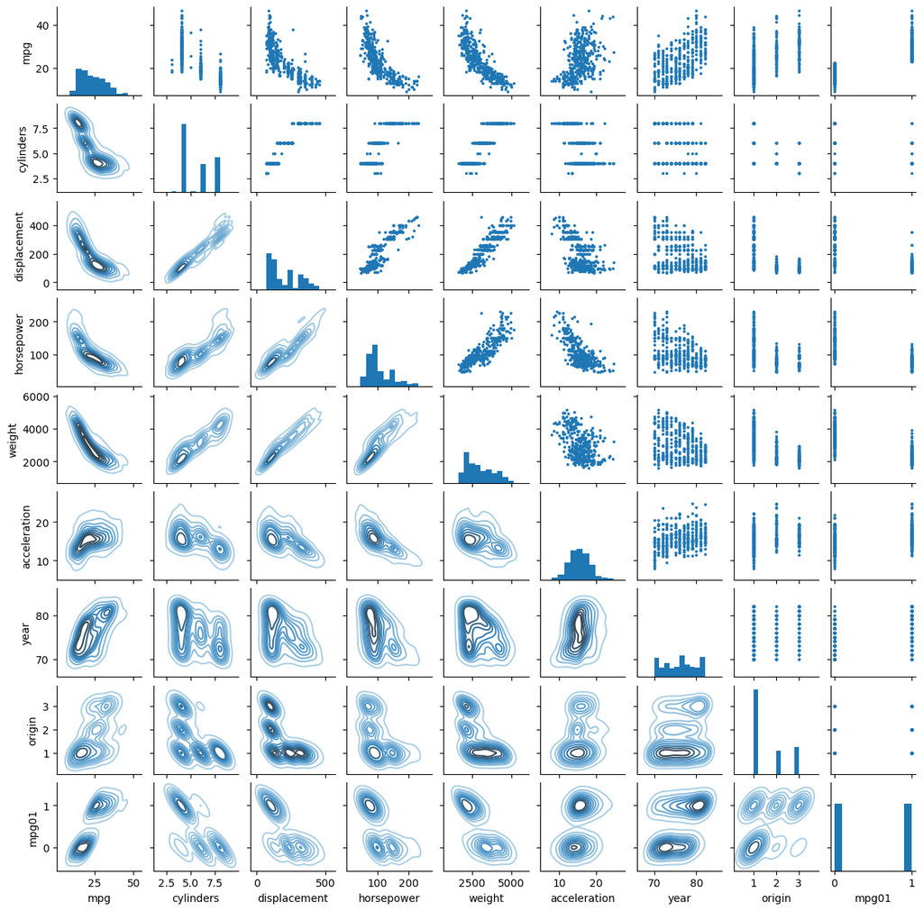

```python
g = sns.PairGrid(auto_number)
g.map_upper(plt.scatter, s=3)
g.map_diag(plt.hist)
g.map_lower(sns.kdeplot, cmap="Blues_d")
g.fig.set_size_inches(12, 12)
```

From the scatterplots and the last line of the correlation matrix above, we see that mpg01 is highly related to cylinders, displacement and weight.

(c).

Since we learn Cross validation in the next chapter, we only use ramdom split to split the data into training and testing sets.

```python
test_index = np.random.choice(len(auto_number), 100,
                             replace=False)
auto_test = auto_number.iloc[test_index, :]
auto_train = auto_number.drop(test_index)
auto_test.shape, auto_train.shape
```

```
((100, 9), (292, 9))
```

(d).

```python
predictors = ['displacement'
             ,'horsepower'
             ,'weight'
             ,'acceleration'
             ,'year']

X_auto_train = auto_train[predictors]
y_auto_train = auto_train['mpg01']

X_auto_test = auto_test[predictors]
y_auto_test = auto_test['mpg01']

lda = LDA(solver='lsqr')
lda_fit_auto = lda.fit(X_auto_train, y_auto_train)

lda_pred = lda_fit_auto.predict(X_auto_test)
ISLP.confusion_table(y_auto_test, lda_pred)
```

| Truth Predicted | 0 | 1 |
| --- | --- | --- |
| 0 | 41 | 7 |
| 1 | 0 | 52 |

```python
(y_auto_test != lda_pred).mean()
```

```
0.07
```

(e).

```python
qda = QDA()
qda_fit_auto = qda.fit(X_auto_train, y_auto_train)

qda_pred = qda_fit_auto.predict(X_auto_test)
ISLP.confusion_table(y_auto_test, qda_pred)
```

| Truth Predicted | 0 | 1 |
| --- | --- | --- |
| 0 | 42 | 6 |
| 1 | 1 | 51 |

```python
(qda_pred != y_auto_test).mean()
```

```
0.07
```

We may conclude that the test error rate of the model obtained is 7%.

(f).

```python
formula = '+'.join(predictors)
lg_fit_auto = smf.glm(f'mpg01~{formula}',
                     data=auto_train,
                     family=sm.families.Binomial()).fit()

lg_prob = lg_fit_auto.predict(X_auto_test)
lg_pred = np.where(lg_prob>0.5, 1, 0)

ISLP.confusion_table(y_auto_test, lg_pred)
```

| Truth Predicted | 0 | 1 |
| --- | --- | --- |
| 0 | 41 | 7 |
| 1 | 4 | 48 |

```python
(lg_pred != y_auto_test).mean()
```

```
0.11
```

(g).

```python
NB = GaussianNB()
NB_fit_auto = NB.fit(X_auto_train, y_auto_train)

NB_pred = NB_fit_auto.predict(X_auto_test)
print(ISLP.confusion_table(y_auto_test, NB_pred))
(NB_pred != y_auto_test).mean()
```

```
Truth       0   1
Predicted
0          41   7
1           1  51
```

```
0.08
```

(h).

```python
for K in range(0,101,10):
    if K == 0:
        K = 1
    knn = neighbors.KNeighborsClassifier(n_neighbors=K)
    knn.fit(X_auto_train, y_auto_train)
    error_rate = (knn.predict(X_auto_test) != y_auto_test).mean()
    print(f'K = {K}, error rate = {error_rate:.2%}')
```

```
K = 1, error rate = 8.00%
K = 10, error rate = 8.00%
K = 20, error rate = 11.00%
K = 30, error rate = 11.00%
K = 40, error rate = 11.00%
K = 50, error rate = 11.00%
K = 60, error rate = 11.00%
K = 70, error rate = 12.00%
K = 80, error rate = 12.00%
K = 90, error rate = 12.00%
K = 100, error rate = 11.00%
```

## Question 5.5

```python
import pandas as pd
import numpy as np
import patsy
import seaborn as sns
import matplotlib.pyplot as plt
from ISLP import load_data
import statsmodels.formula.api as smf
from sklearn.model_selection import train_test_split
from sklearn.linear_model import LogisticRegression
from sklearn.metrics import confusion_matrix
```

(a).

```python
Default=load_data("Default")
Default.head()
```

|  | default | student | balance | income |
| --- | --- | --- | --- | --- |
| 0 | No | No | 729.526495 | 44361.625074 |
| 1 | No | Yes | 817.180407 | 12106.134700 |
| 2 | No | No | 1073.549164 | 31767.138947 |
| 3 | No | No | 529.250605 | 35704.493935 |
| 4 | No | No | 785.655883 | 38463.495879 |

```python
lg_fit = smf.glm('default~income+balance',
                 data=Default,
                 family=sm.families.Binomial()).fit()
lg_fit.summary()
```

Generalized Linear Model Regression Results

| Dep. Variable: | ['default[No]', 'default[Yes]'] | No. Observations: | 10000 |
| --- | --- | --- | --- |
| Model: | GLM | Df Residuals: | 9997 |
| Model Family: | Binomial | Df Model: | 2 |
| Link Function: | Logit | Scale: | 1.0000 |
| Method: | IRLS | Log-Likelihood: | -789.48 |
| Date: | Mon, 04 Nov 2024 | Deviance: | 1579.0 |
| Time: | 22:18:35 | Pearson chi2: | 6.95e+03 |
| No. Iterations: | 9 | Pseudo R-squ. (CS): | 0.1256 |
| Covariance Type: | nonrobust |  |  |

|  | coef | std err | z | P>\|z\| | [0.025 | 0.975] |
| --- | --- | --- | --- | --- | --- | --- |
| Intercept | 11.5405 | 0.435 | 26.544 | 0.000 | 10.688 | 12.393 |
| income | -2.081e-05 | 4.99e-06 | -4.174 | 0.000 | -3.06e-05 | -1.1e-05 |
| balance | -0.0056 | 0.000 | -24.835 | 0.000 | -0.006 | -0.005 |

(b).

(i).

```python
Default_train, Default_valid = train_test_split(Default, test_size=5000, random_state=0)
Default_valid
```

|  | default | student | balance | income |
| --- | --- | --- | --- | --- |
| 9394 | No | Yes | 0.000000 | 13911.441282 |
| 898 | No | No | 396.985985 | 55454.631040 |
| 2398 | No | No | 1046.416673 | 47598.307369 |
| 5906 | No | No | 836.343137 | 34559.158405 |
| 2343 | No | Yes | 534.692907 | 18729.566240 |
| ... | ... | ... | ... | ... |
| 3996 | No | No | 794.176213 | 43335.985041 |
| 5889 | No | No | 81.531865 | 40847.811311 |
| 4577 | No | No | 1137.791157 | 21103.429621 |
| 8600 | No | No | 646.081240 | 36686.959447 |
| 847 | No | No | 388.548350 | 18007.832960 |

5000 rows × 4 columns

(ii.)

```python
allvars_train = Default_train.columns.drop(['default','student'])
design_train=MS(allvars_train)
X_train=design_train.fit_transform(Default_train)
y_train=Default_train.default=='Yes'
glm=sm.GLM(y_train,X_train,family=sm.families.Binomial())
res=glm.fit()
res.summary()
```

Generalized Linear Model Regression Results

| Dep. Variable: | default | No. Observations: | 5000 |
| --- | --- | --- | --- |
| Model: | GLM | Df Residuals: | 4997 |
| Model Family: | Binomial | Df Model: | 2 |
| Link Function: | Logit | Scale: | 1.0000 |
| Method: | IRLS | Log-Likelihood: | -364.78 |
| Date: | Mon, 04 Nov 2024 | Deviance: | 729.56 |
| Time: | 22:44:46 | Pearson chi2: | 2.57e+03 |
| No. Iterations: | 9 | Pseudo R-squ. (CS): | 0.1125 |
| Covariance Type: | nonrobust |  |  |

|  | coef | std err | z | P>\|z\| | [0.025 | 0.975] |
| --- | --- | --- | --- | --- | --- | --- |
| intercept | -11.3896 | 0.635 | -17.935 | 0.000 | -12.634 | -10.145 |
| balance | 0.0056 | 0.000 | 16.792 | 0.000 | 0.005 | 0.006 |
| income | 1.58e-05 | 7.34e-06 | 2.151 | 0.031 | 1.4e-06 | 3.02e-05 |

(iii.)

```python
X_valid=design_train.transform(Default_valid)
valid_pred = res.predict(X_valid)
labels=np.array(['No']*5000)
labels[valid_pred>0.5]='Yes'
```

(iv).

```python
y_true = Default_valid['default']
misclassified = np.sum(y_true != labels)
validation_error_rate = misclassified / len(labels)
validation_error_rate
```

```
0.0398
```

(c).

```python
from sklearn.linear_model import LogisticRegression
from sklearn.metrics import confusion_matrix
import numpy as np

def total_error_rate(confusion_mtx):
    return (confusion_mtx[0, 1] + confusion_mtx[1, 0]) / np.sum(confusion_mtx)

for seed in range(1, 4):
    print(f"\nRandom seed = {seed}")
    np.random.seed(seed)

    Default_train, Default_valid = train_test_split(Default, test_size=0.5, random_state=seed)
    X_train = Default_train[['income', 'balance']].values
    y_train = (Default_train['default'] == 'Yes').values
    X_valid = Default_valid[['income', 'balance']].values
    y_valid = (Default_valid['default'] == 'Yes').values
    logit_model = LogisticRegression()
    model_logit = logit_model.fit(X_train, y_train)

    y_pred_prob = model_logit.predict_proba(X_valid)[:, 1]
    y_pred = np.where(y_pred_prob > 0.5, 1, 0)
    confusion_mtx = confusion_matrix(y_valid, y_pred)

    print("Confusion Matrix:")
    print(confusion_mtx)

    error_rate = total_error_rate(confusion_mtx)
    print(f"Total error rate: {error_rate:.4f}")
```

```
Random seed = 1
Confusion Matrix:
[[4817   24]
 [ 101   58]]
Total error rate: 0.0250

Random seed = 2
Confusion Matrix:
[[4824   22]
 [ 102   52]]
Total error rate: 0.0248

Random seed = 3
Confusion Matrix:
[[4817   14]
 [ 110   59]]
Total error rate: 0.0248
```

We see that the validation estimate of the test error rate can be variable, depending on precisely which observations are included in the training set and which observations are included in the validation set. However, in this case, the error rate is almost the same for all three random seeds and validation sets, which means that the error rate is reliable.

(d).

```python
def total_error_rate(confusion_mtx):
    return (confusion_mtx[0, 1] + confusion_mtx[1, 0]) / np.sum(confusion_mtx)

for seed in range(1, 4):
    np.random.seed(seed)
    print(f"\nRandom seed = {seed}")
    train = np.random.rand(len(Default)) < 0.5
    predictors = ['income', 'balance', 'student_Yes']
    X_train = np.array(Default[train][predictors])
    X_test = np.array(Default[~train][predictors])

    y_train = np.where(Default[train]['default'] == 'Yes', 1, 0)
    y_test = np.where(Default[~train]['default'] == 'Yes', 1, 0)

    logit = LogisticRegression()
    model_logit = logit.fit(X_train, y_train)

    y_pred = model_logit.predict(X_test)

    confusion_mtx = confusion_matrix(y_test, y_pred)

    print("Confusion Matrix:")
    print(confusion_mtx)

    total_error_rate_pct = np.around(total_error_rate(confusion_mtx) * 100, 4)
    print(f'Total error rate: {total_error_rate_pct}%')
```

```
Random seed = 1
Confusion Matrix:
[[4826   20]
 [ 111   53]]
Total error rate: 2.6148%

Random seed = 2
Confusion Matrix:
[[4674   18]
 [ 126   50]]
Total error rate: 2.9581%

Random seed = 3
Confusion Matrix:
[[4747   27]
 [ 111   52]]
Total error rate: 2.7952%
```

It doesn't seem that adding the "student" dummy variable leads to a reduction in the validation set estimate of the test error rate.

## Question 5.6

(a).

```python
Default=load_data("Default")
Default.head()
```

|  | default | student | balance | income |
| --- | --- | --- | --- | --- |
| 0 | No | No | 729.526495 | 44361.625074 |
| 1 | No | Yes | 817.180407 | 12106.134700 |
| 2 | No | No | 1073.549164 | 31767.138947 |
| 3 | No | No | 529.250605 | 35704.493935 |
| 4 | No | No | 785.655883 | 38463.495879 |

```python
Default['default_yes'] = (Default['default'] == 'Yes').astype('int')
allvars=Default.columns.drop(['default','student','default_yes'])
design=MS(allvars)
X=design.fit_transform(Default)
y=Default.default=='Yes'
model=sm.GLM(y,X,family=sm.families.Binomial())
result=model.fit()
summarize(result)
```

|  | coef | std err | z | P>\|z\| |
| --- | --- | --- | --- | --- |
| intercept | -11.540500 | 0.435000 | -26.544 | 0.0 |
| balance | 0.005600 | 0.000000 | 24.835 | 0.0 |
| income | 0.000021 | 0.000005 | 4.174 | 0.0 |

standard error:

```python
result.bse
```

```
intercept    0.434772
balance      0.000227
income       0.000005
dtype: float64
```

(b).

```python
from sklearn.base import clone
def boot_SE(func,D,n=None,B=1000,seed=0):
    rng = np.random.default_rng(seed)
    first_, second_ = 0, 0
    n = n or D.shape[0]
    for _ in range(B):
        idx = rng.choice(D.index,n,replace=True)
        value = func(D,idx)
        first_ += value
        second_ += value**2
    return np.sqrt(second_ / B - (first_ / B)**2)
def boot_fn(model_matrix,response,D,idx):
    D_=D.loc[idx]
    y=D_[response]
    X=clone(model_matrix).fit_transform(D_)
    model=sm.GLM(y,X,family=sm.families.Binomial())
    result=model.fit()
    coef_income=result.params[1]
    coef_balance=result.params[2]
    return result.params
```

(c).

```python
from functools import partial
hp_func=partial(boot_fn,MS(['income','balance']),'default_yes')
rng = np.random.default_rng(0)
np.array([hp_func(Default,
          rng.choice(392,
                     392,
                     replace=True)) for _ in range(10)])
```

[output not shown]

[output cut: 14 more lines]

```
array([[-1.37418699e+01,  4.46108654e-05,  6.54456450e-03],
       [-9.73343593e+00,  1.29161125e-05,  4.36172555e-03],
       [-1.09652934e+01,  6.88991070e-06,  5.60127348e-03],
       [-1.29994735e+01,  5.80207964e-05,  5.99463447e-03],
       [-1.76482871e+01,  3.85717484e-05,  8.94706073e-03],
       [-1.37799054e+01,  7.20354708e-05,  5.64428958e-03],
       [-1.00286504e+01,  1.25804073e-05,  5.16837631e-03],
       [-1.36627122e+01,  3.52359713e-05,  6.88246994e-03],
       [-1.30954565e+01,  8.56134990e-06,  7.38734450e-03],
       [-1.41538872e+01,  3.45878793e-05,  7.22152035e-03]])
```

```python
boot_SE(hp_func,Default,B=1000,seed=10)
```

[output not shown]

[output cut: 3974 more lines]

```
intercept    0.425280
income       0.000005
balance      0.000227
dtype: float64
```

(d).

#### Observation:

**Use SM The standard error obtained by GLM() is**:  
intercept: 0.434772  
income: 0.000005  
balance: 0.000227  
**Standard error obtained using bootstrap**:  
intercept: 0.425280  
income: 0.000005  
balance: 0.000227

#### Conclusion:

1. The standard errors obtained from sm.GLM() and bootstrap are very similar across all parameters (intercept, income, and balance). The small differences in the intercept's standard error (0.434772 vs. 0.425280) are negligible and well within a reasonable margin of error.
2. Bootstrap is often used to verify the robustness of the standard errors, especially when the assumptions behind analytical methods (such as sm.GLM()) might not hold perfectly. In this case, both methods yield almost identical results, which suggests that the assumptions of the GLM model are reasonably valid, and the model has been fitted well.
3. Bootstrap provides an empirical estimate of standard errors by repeatedly resampling the data. When bootstrap and analytical methods give similar results, this indicates that the dataset is large enough, and the model assumptions (like normality of errors) are likely met.